# RM-ANOVA for coevolution with a seed bank

## Population density data

I have previously consolidated all the data on population density collected for this experiment. This includes:

| Population | What it is | Method of measurement |
| --- | --- | --- |
| spore / mL | host spore density | flow-cytometry: low SYBR population |
| veg / mL | host vegetative cell density | flow-cytometry: high SYBR population |
| cell /mL | total host cell density (spore+veg) | flow-cytometry |
| phage/ mL | total SPO1 phage density (free phage) | qPCR (SYBR) with phage specific primers and lysate serial dilution as standard |

In the first few days of the experiment cell numbers dropped below detection limit in 2 of 3 SNO lines. Missing data cannot be analyzed in RM-ANOVA. I will assign these points the detection limit values.

Points with missing data:

```r
d%>%
  filter(cell.ml<10)
```

| culture | line | Time | seed.bank | phage.ml | spore.ml | veg.ml | cell.ml | host | phage | flask |
| --- | --- | --- | --- | --- | --- | --- | --- | --- | --- | --- |
| SNO | L2 | 2.5 | none | 531673865 | 1 | 1 | 2 | dSpoIIE | SPO1 | SNO-L2 |
| SNO | L3 | 2.5 | none | 697684098 | 1 | 1 | 2 | dSpoIIE | SPO1 | SNO-L3 |
| SNO | L2 | 3.0 | none | 3627628662 | 1 | 1 | 2 | dSpoIIE | SPO1 | SNO-L2 |

These are all veg cells:

```r
d%>%
  filter(veg.ml<10)
```

[output not shown]

**Flow-cytometry detection limit**

The flow cytometer stop conditions were either $50\mu L$ or 50,000 events, whatever came first.  
In addition, to account for false asignments by noise I required that a gated population have at least 100 events to be taken into account. So the minimal detected population would have 100 cells in $50\mu L$ of analyzed liquid. At this poimt of the experiment we were analyzing x100 diluted samples.

```r
detection.limit <- 100 * (1000/50) * 100
```

## I will use $1X10^5$, half the detection limit dor missing value points

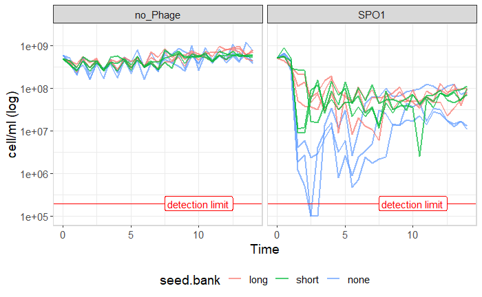

```r
d <- d%>%
  mutate(cell.ml=if_else(cell.ml>10, cell.ml,detection.limit/2))%>%
  mutate(veg.ml=if_else(veg.ml>10, veg.ml,detection.limit/2))
# plot total cells of raw data
d%>%
    ggplot(aes(x=Time, y=cell.ml))+
      geom_line(aes(group=flask,color=seed.bank), size=1, alpha=0.7)+
  geom_hline(yintercept = detection.limit, color="red")+
  geom_label(label="detection limit", x=10, y=log10(detection.limit), color="red")+
      facet_wrap(~phage)+
      theme_bw()+
      panel_border()+
      scale_y_log10()+
      theme(legend.position = "bottom",
            text=element_text(size=14))+
      ylab("cell/ml (log)")+
      coord_cartesian(ylim = c(1e5, 2e9))
```

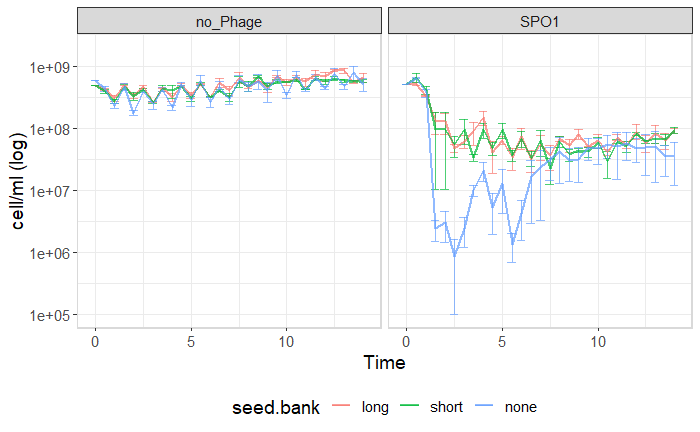

```r
# plot total cells of raw data
d%>%
  group_by(phage,seed.bank,Time)%>%
  summarise(n=n(),sd=sd(cell.ml), cell.ml=mean(cell.ml), sem=sd/sqrt(n))%>%
    ggplot(aes(x=Time, y=cell.ml))+
  geom_errorbar(aes(ymin=cell.ml-sem,ymax=cell.ml+sem,color=seed.bank), alpha=0.7)+
      geom_line(aes(color=seed.bank), size=1, alpha=0.7)+
      facet_wrap(~phage)+
      theme_bw()+
      panel_border()+
      scale_y_log10()+
      theme(legend.position = "bottom",
            text=element_text(size=14))+
      ylab("cell/ml (log)")+
      coord_cartesian(ylim = c(1e5, 2e9))
```

# Adjusting variable types for lme

In the lme models I will be using the fixd effects need to be secified as factore, in this experiment these ar: *Phage, seed.bank and time*. However for the autocorrelation specification time needs to be specified as an integer. To fulfill both requirements I will use for the time unit the experimental day rather than transfer, since we measured onc a day but twice per transfer. This will be simplty *time x 2*. I will then make fom that a separate varible which will be the factor of the time.

```r
d.4stat <-
  d%>%
  # remove setup data
  filter(Time>=0)%>%
  #make time an integer for correlation structure
  # by converting to days as time unit
  mutate(Time=as.integer(2*Time))%>%
  # for the lme model all fixed effects need to be factors
  mutate(time.fct=as.factor(Time))%>%
  mutate(seed.bank=as.factor(seed.bank))%>%
  mutate(phage=as.factor(phage))
```

## Model selection

### ARMA covariance

This is a combined auto-regeressive model, AR(p) and moving average model, MA(q). I here take a model selection approach to choose these parameters (lowest AIC).

```r
# initalise empty table
pq.aic <- tibble(p=1, q=1,aic=1)%>%
  filter(p>1)

# Playing around with p&q I found the space in which the model conerges is limited
for(Q in c(0:2)){
  for (P in c(1:(10-2*Q))){

    #this fllowing combination does not work: "iteration limit reached without convergence"
    if(P>=8 & Q==0) next
     if(P>=7 & Q==1) next
    if(P==1 & Q==2) next
    if(P>=6 & Q==2) next

    cur.model <-
        d.4stat%>%
  # looking only at total cells (cell.ml)
    lme(cell.ml ~ phage * seed.bank * time.fct , random = ~1|flask,
            correlation = corARMA(form = ~ Time | flask, p=P,q=Q),
            data = .)

    pq.aic <-
      tibble(p=P, q=Q,aic=AIC(cur.model))%>%
      bind_rows(pq.aic,.)

  }
}
pq.aic%>%arrange(aic)
```

| p | q | aic |
| --- | --- | --- |
| 5 | 0 | 14192.54 |
| 6 | 0 | 14194.54 |
| 5 | 1 | 14194.54 |
| 1 | 1 | 14195.09 |
| 2 | 0 | 14195.33 |
| 1 | 0 | 14195.36 |
| 2 | 1 | 14196.33 |
| 5 | 2 | 14196.53 |
| 7 | 0 | 14196.53 |
| 6 | 1 | 14196.54 |

[output cut: 7 more lines]

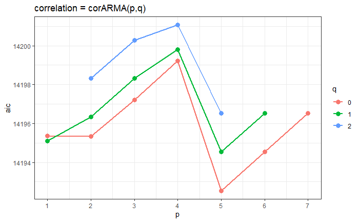

```r
pq.aic%>%
  mutate(q=as.character(q))%>%
  ggplot(aes(p,aic))+
  geom_line(aes(color=q),size=1)+
  geom_point(aes(color=q),size=3)+
  theme_bw()+
  scale_x_continuous(breaks = 1:10)+
  ggtitle("correlation = corARMA(p,q)")
```

```r
NA
NA
```

I will test the best 5 models against AR1,

### compare AR1 with ARMA

```r
l.rm <- list()

pq.best <- pq.aic%>%
  slice_min( order_by=aic,n=5)

for (i in 1:nrow(pq.best)){
  l.rm[[i]] <-
    d.4stat%>%
    # looking only at total cells (cell.ml)
    lme(cell.ml ~ phage * seed.bank * time.fct ,
        random = ~1|flask,
        correlation = corARMA(form = ~ Time | flask,
                              p=pq.best$p[i],
                              q=pq.best$q[i]),
        data = .)

}


# add corAR1 to list
l.rm[[i+1]] <-
  d.4stat%>%
  # looking only at total cells (cell.ml)
    lme(cell.ml ~ phage * seed.bank * time.fct ,
        random = ~1|flask,
        correlation = corAR1(form = ~ Time | flask),
        data = .)


# get list order by AIC
aic.l <- sapply(l.rm,AIC)%>%
  sort.list()


# compare models by AIC order
anova.lme(l.rm[[aic.l[6]]],
          l.rm[[aic.l[5]]],
          l.rm[[aic.l[4]]],
          l.rm[[aic.l[3]]],
          l.rm[[aic.l[2]]],
          l.rm[[aic.l[1]]])
```

|  | Model | df | AIC | BIC | logLik | Test | L.Ratio | p-value |
| --- | --- | --- | --- | --- | --- | --- | --- | --- |
| l.rm[[aic.l[6]]] | 1 | 177 | 14195.36 | 14877.20 | -6920.682 |  |  |  |
| l.rm[[aic.l[5]]] | 2 | 178 | 14195.33 | 14881.03 | -6919.667 | 1 vs 2 | 2.029323 | 0.1543 |
| l.rm[[aic.l[4]]] | 3 | 178 | 14195.09 | 14880.78 | -6919.544 |  |  |  |
| l.rm[[aic.l[3]]] | 4 | 182 | 14194.54 | 14895.64 | -6915.268 | 3 vs 4 | 8.551136 | 0.0734 |
| l.rm[[aic.l[2]]] | 5 | 182 | 14194.54 | 14895.64 | -6915.268 |  |  |  |
| l.rm[[aic.l[1]]] | 6 | 181 | 14192.54 | 14889.79 | -6915.270 | 5 vs 6 | 0.003703 | 0.9515 |

The best model is not significantly better than any of the other ARMA models. Looking at model 6 (corAR1), has the least degrees of freedom (df=177) :

```r
#display best model results
tmp <- summary(l.rm[[aic.l[6]]])
tmp$call
```

```
lme.formula(fixed = cell.ml ~ phage * seed.bank * time.fct, data = .,
    random = ~1 | flask, correlation = corAR1(form = ~Time |
        flask))
```

```r
  anova(l.rm[[aic.l[6]]])
```

|  | numDF | denDF | F-value | p-value |
| --- | --- | --- | --- | --- |
| (Intercept) | 1 | 336 | 2368.2534 | <.0001 |
| phage | 1 | 12 | 986.1352 | <.0001 |
| seed.bank | 2 | 12 | 4.0142 | 0.0463 |
| time.fct | 28 | 336 | 17.8685 | <.0001 |
| phage:seed.bank | 2 | 12 | 1.2543 | 0.3201 |
| phage:time.fct | 28 | 336 | 26.4863 | <.0001 |
| seed.bank:time.fct | 56 | 336 | 1.9517 | 0.0002 |
| phage:seed.bank:time.fct | 56 | 336 | 1.4433 | 0.0273 |

The model coAR1 was chosen. **There is a significant interaction between phage,seed.bank and time effecting population density.**

How sensetive would the result be to model selected?

```r
tmp <- map(l.rm, anova.lme)
tmp1 <- map(l.rm, getCall)

for(i in 1:6){
  print(tmp1[[i]])
  if(i<6) print(paste("p=",pq.best$p[i],"q=",pq.best$q[i]))

  print(tmp[[i]])
}
```

```
lme.formula(fixed = cell.ml ~ phage * seed.bank * time.fct, data = .,
    random = ~1 | flask, correlation = corARMA(form = ~Time |
        flask, p = pq.best$p[i], q = pq.best$q[i]))
[1] "p= 5 q= 0"
```

|  | numDF | denDF | F-value | p-value |
| --- | --- | --- | --- | --- |
| (Intercept) | 1 | 336 | 2407.7088 | <.0001 |
| phage | 1 | 12 | 940.1624 | <.0001 |
| seed.bank | 2 | 12 | 4.3342 | 0.0383 |
| time.fct | 28 | 336 | 23.0074 | <.0001 |
| phage:seed.bank | 2 | 12 | 1.4412 | 0.2748 |
| phage:time.fct | 28 | 336 | 32.8577 | <.0001 |
| seed.bank:time.fct | 56 | 336 | 2.5285 | <.0001 |
| phage:seed.bank:time.fct | 56 | 336 | 1.7521 | 0.0015 |

```
lme.formula(fixed = cell.ml ~ phage * seed.bank * time.fct, data = .,
    random = ~1 | flask, correlation = corARMA(form = ~Time |
        flask, p = pq.best$p[i], q = pq.best$q[i]))
[1] "p= 6 q= 0"
```

|  | numDF | denDF | F-value | p-value |
| --- | --- | --- | --- | --- |
| (Intercept) | 1 | 336 | 2418.3762 | <.0001 |
| phage | 1 | 12 | 945.1981 | <.0001 |
| seed.bank | 2 | 12 | 4.3536 | 0.0379 |
| time.fct | 28 | 336 | 23.0566 | <.0001 |
| phage:seed.bank | 2 | 12 | 1.4442 | 0.2742 |
| phage:time.fct | 28 | 336 | 32.9792 | <.0001 |
| seed.bank:time.fct | 56 | 336 | 2.5372 | <.0001 |
| phage:seed.bank:time.fct | 56 | 336 | 1.7566 | 0.0014 |

```
lme.formula(fixed = cell.ml ~ phage * seed.bank * time.fct, data = .,
    random = ~1 | flask, correlation = corARMA(form = ~Time |
        flask, p = pq.best$p[i], q = pq.best$q[i]))
[1] "p= 5 q= 1"
```

|  | numDF | denDF | F-value | p-value |
| --- | --- | --- | --- | --- |
| (Intercept) | 1 | 336 | 2417.4839 | <.0001 |
| phage | 1 | 12 | 944.7779 | <.0001 |
| seed.bank | 2 | 12 | 4.3521 | 0.0379 |
| time.fct | 28 | 336 | 23.0549 | <.0001 |
| phage:seed.bank | 2 | 12 | 1.4440 | 0.2742 |
| phage:time.fct | 28 | 336 | 32.9734 | <.0001 |
| seed.bank:time.fct | 56 | 336 | 2.5368 | <.0001 |
| phage:seed.bank:time.fct | 56 | 336 | 1.7564 | 0.0014 |

```
lme.formula(fixed = cell.ml ~ phage * seed.bank * time.fct, data = .,
    random = ~1 | flask, correlation = corARMA(form = ~Time |
        flask, p = pq.best$p[i], q = pq.best$q[i]))
[1] "p= 1 q= 1"
```

|  | numDF | denDF | F-value | p-value |
| --- | --- | --- | --- | --- |
| (Intercept) | 1 | 336 | 2355.5191 | <.0001 |
| phage | 1 | 12 | 1004.5607 | <.0001 |
| seed.bank | 2 | 12 | 4.2940 | 0.0392 |
| time.fct | 28 | 336 | 20.1427 | <.0001 |
| phage:seed.bank | 2 | 12 | 1.2658 | 0.3171 |
| phage:time.fct | 28 | 336 | 30.5127 | <.0001 |
| seed.bank:time.fct | 56 | 336 | 2.1924 | <.0001 |
| phage:seed.bank:time.fct | 56 | 336 | 1.5583 | 0.0098 |

```
lme.formula(fixed = cell.ml ~ phage * seed.bank * time.fct, data = .,
    random = ~1 | flask, correlation = corARMA(form = ~Time |
        flask, p = pq.best$p[i], q = pq.best$q[i]))
[1] "p= 2 q= 0"
```

|  | numDF | denDF | F-value | p-value |
| --- | --- | --- | --- | --- |
| (Intercept) | 1 | 336 | 2350.5809 | <.0001 |
| phage | 1 | 12 | 1007.5500 | <.0001 |
| seed.bank | 2 | 12 | 4.2801 | 0.0395 |
| time.fct | 28 | 336 | 19.5328 | <.0001 |
| phage:seed.bank | 2 | 12 | 1.2524 | 0.3206 |
| phage:time.fct | 28 | 336 | 29.5805 | <.0001 |
| seed.bank:time.fct | 56 | 336 | 2.1173 | <.0001 |
| phage:seed.bank:time.fct | 56 | 336 | 1.5312 | 0.0126 |

```
lme.formula(fixed = cell.ml ~ phage * seed.bank * time.fct, data = .,
    random = ~1 | flask, correlation = corAR1(form = ~Time |
        flask))
```

|  | numDF | denDF | F-value | p-value |
| --- | --- | --- | --- | --- |
| (Intercept) | 1 | 336 | 2368.2534 | <.0001 |
| phage | 1 | 12 | 986.1352 | <.0001 |
| seed.bank | 2 | 12 | 4.0142 | 0.0463 |
| time.fct | 28 | 336 | 17.8685 | <.0001 |
| phage:seed.bank | 2 | 12 | 1.2543 | 0.3201 |
| phage:time.fct | 28 | 336 | 26.4863 | <.0001 |
| seed.bank:time.fct | 56 | 336 | 1.9517 | 0.0002 |
| phage:seed.bank:time.fct | 56 | 336 | 1.4433 | 0.0273 |

All models show the same story:  
* The interaction of interaction between phage,seed.bank and time is significant in influencing cell density. The selected model (#6) actually has the highest (i.e. “worst”) p-value for the 3 way interaction.

=================

# Host density by host

=================

I will repeat the same anlysis but will treat the seed-bank as a 2-level factor: with (WT host) or without ($\Delta$spoIIE) a seed bank.

## Model selection

### ARMA covariance

This is a combined auto-regeressive model, AR(p) and moving average model, MA(q). I here take a model selection approach to choose these parameters (lowest AIC).

```r
# initalise empty table
pq.aic <- tibble(p=1, q=1,aic=1)%>%
  filter(p>1)

# Playing around with p&q I found the sappce in which the model convergence is limited
for(Q in c(0:2)){
  for (P in c(1:(10-3*Q))){

    #this fllowing combination does not work: "iteration limit reached without convergence"
    if(P>=1 & Q==2) next
    if(P>=8 & Q==0) next
    if(P>=7 & Q==1) next
    # if(P>=3 & Q==2) next

    cur.model <-
        d.4stat%>%
  # looking only at total cells (cell.ml)
    lme(cell.ml ~ phage * seed.bank * time.fct , random = ~1|flask,
            correlation = corARMA(form = ~ Time | flask, p=P,q=Q),
            data = .)

    pq.aic <-
      tibble(p=P, q=Q,aic=AIC(cur.model))%>%
      bind_rows(pq.aic,.)

  }
}
pq.aic%>%arrange(aic)
```

| p | q | aic |
| --- | --- | --- |
| 5 | 0 | 14192.54 |
| 6 | 0 | 14194.54 |
| 5 | 1 | 14194.54 |
| 1 | 1 | 14195.09 |
| 2 | 0 | 14195.33 |
| 1 | 0 | 14195.36 |
| 2 | 1 | 14196.33 |
| 7 | 0 | 14196.53 |
| 6 | 1 | 14196.54 |
| 3 | 0 | 14197.21 |

[output cut: 3 more lines]

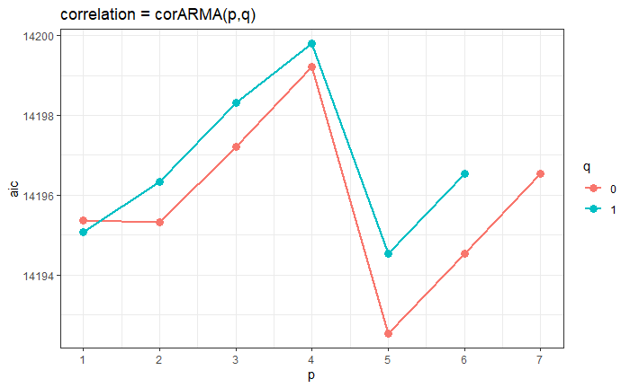

```r
pq.aic%>%
  mutate(q=as.character(q))%>%
  ggplot(aes(p,aic))+
  geom_line(aes(color=q),size=1)+
  geom_point(aes(color=q),size=3)+
  theme_bw()+
  scale_x_continuous(breaks = 1:10)+
  ggtitle("correlation = corARMA(p,q)")
```

```r
NA
NA
```

I will test the best 5 models against AR1,

### compare AR1 with ARMA

```r
l.rm <- list()

pq.best <- pq.aic%>%
  slice_min( order_by=aic,n=5)

for (i in 1:nrow(pq.best)){
  l.rm[[i]] <-
    d.4stat%>%
    # looking only at total cells (cell.ml)
    lme(cell.ml ~ phage * host * time.fct , random = ~1|flask,
            correlation = corARMA(form = ~ Time | flask,
                                  p=pq.best$p[i],q=pq.best$q[i]),
            data = .)

}


# add corAR1 to list
l.rm[[i+1]] <-
  d.4stat%>%
  # looking only at total cells (cell.ml)
    lme(cell.ml ~ phage * host * time.fct , random = ~1|flask,
            correlation = corAR1(form = ~ Time | flask),
            data = .)


# get list order by AIC
aic.l <- sapply(l.rm,AIC)%>%
  sort.list()


# compare models by AIC order
anova.lme(l.rm[[aic.l[6]]],
          l.rm[[aic.l[5]]],
          l.rm[[aic.l[4]]],
          l.rm[[aic.l[3]]],
          l.rm[[aic.l[2]]],
          l.rm[[aic.l[1]]])
```

|  | Model | df | AIC | BIC | logLik | Test | L.Ratio | p-value |
| --- | --- | --- | --- | --- | --- | --- | --- | --- |
| l.rm[[aic.l[6]]] | 1 | 124 | 16321.80 | 16818.59 | -8036.900 |  |  |  |
| l.rm[[aic.l[5]]] | 2 | 124 | 16321.80 | 16818.59 | -8036.900 |  |  |  |
| l.rm[[aic.l[4]]] | 3 | 119 | 16320.38 | 16797.14 | -8041.191 | 2 vs 3 | 8.581873 | 0.1269 |
| l.rm[[aic.l[3]]] | 4 | 120 | 16320.17 | 16800.94 | -8040.087 | 3 vs 4 | 2.206631 | 0.1374 |
| l.rm[[aic.l[2]]] | 5 | 123 | 16319.80 | 16812.58 | -8036.901 | 4 vs 5 | 6.373347 | 0.0948 |
| l.rm[[aic.l[1]]] | 6 | 120 | 16319.62 | 16800.38 | -8039.810 | 5 vs 6 | 5.819751 | 0.1207 |

The best model is not significantly better than any of the other ARMA models. Looking at model 4, has the least degrees of freedom (df=119), This is the coAR1 model :

```r
#display best model results
getCall(l.rm[[aic.l[4]]])
```

```
lme.formula(fixed = cell.ml ~ phage * host * time.fct, data = .,
    random = ~1 | flask, correlation = corAR1(form = ~Time |
        flask))
```

```r
  anova.lme(l.rm[[aic.l[4]]])
```

|  | numDF | denDF | F-value | p-value |
| --- | --- | --- | --- | --- |
| (Intercept) | 1 | 392 | 1963.8689 | <.0001 |
| phage | 1 | 14 | 816.4676 | <.0001 |
| host | 1 | 14 | 4.6669 | 0.0486 |
| time.fct | 28 | 392 | 18.4089 | <.0001 |
| phage:host | 1 | 14 | 0.0020 | 0.9649 |
| phage:time.fct | 28 | 392 | 27.3061 | <.0001 |
| host:time.fct | 28 | 392 | 3.3080 | <.0001 |
| phage:host:time.fct | 28 | 392 | 2.1582 | 0.0007 |

The model wirth coAR1 was chosen. **There is a significant interaction between phage,seed.bank and time effecting population density.**

How sensetive would the result be to model selected?

```r
tmp <- map(l.rm, anova.lme)
tmp1 <- map(l.rm, getCall)

for(i in 1:6){
  print(tmp1[[i]])
  if(i<6) print(paste("p=",pq.best$p[i],"q=",pq.best$q[i]))

  print(tmp[[i]])
}
```

```
lme.formula(fixed = cell.ml ~ phage * host * time.fct, data = .,
    random = ~1 | flask, correlation = corARMA(form = ~Time |
        flask, p = pq.best$p[i], q = pq.best$q[i]))
[1] "p= 5 q= 0"
```

|  | numDF | denDF | F-value | p-value |
| --- | --- | --- | --- | --- |
| (Intercept) | 1 | 392 | 2075.4695 | <.0001 |
| phage | 1 | 14 | 803.2860 | <.0001 |
| host | 1 | 14 | 5.0731 | 0.0409 |
| time.fct | 28 | 392 | 22.8591 | <.0001 |
| phage:host | 1 | 14 | 0.0005 | 0.9827 |
| phage:time.fct | 28 | 392 | 32.5727 | <.0001 |
| host:time.fct | 28 | 392 | 4.3026 | <.0001 |
| phage:host:time.fct | 28 | 392 | 2.6411 | <.0001 |

```
lme.formula(fixed = cell.ml ~ phage * host * time.fct, data = .,
    random = ~1 | flask, correlation = corARMA(form = ~Time |
        flask, p = pq.best$p[i], q = pq.best$q[i]))
[1] "p= 6 q= 0"
```

|  | numDF | denDF | F-value | p-value |
| --- | --- | --- | --- | --- |
| (Intercept) | 1 | 392 | 2077.1145 | <.0001 |
| phage | 1 | 14 | 802.8065 | <.0001 |
| host | 1 | 14 | 5.0721 | 0.0409 |
| time.fct | 28 | 392 | 22.8205 | <.0001 |
| phage:host | 1 | 14 | 0.0005 | 0.9825 |
| phage:time.fct | 28 | 392 | 32.4708 | <.0001 |
| host:time.fct | 28 | 392 | 4.2920 | <.0001 |
| phage:host:time.fct | 28 | 392 | 2.6349 | <.0001 |

```
lme.formula(fixed = cell.ml ~ phage * host * time.fct, data = .,
    random = ~1 | flask, correlation = corARMA(form = ~Time |
        flask, p = pq.best$p[i], q = pq.best$q[i]))
[1] "p= 5 q= 1"
```

|  | numDF | denDF | F-value | p-value |
| --- | --- | --- | --- | --- |
| (Intercept) | 1 | 392 | 2077.0001 | <.0001 |
| phage | 1 | 14 | 802.7965 | <.0001 |
| host | 1 | 14 | 5.0721 | 0.0409 |
| time.fct | 28 | 392 | 22.8233 | <.0001 |
| phage:host | 1 | 14 | 0.0005 | 0.9825 |
| phage:time.fct | 28 | 392 | 32.4769 | <.0001 |
| host:time.fct | 28 | 392 | 4.2928 | <.0001 |
| phage:host:time.fct | 28 | 392 | 2.6353 | <.0001 |

```
lme.formula(fixed = cell.ml ~ phage * host * time.fct, data = .,
    random = ~1 | flask, correlation = corARMA(form = ~Time |
        flask, p = pq.best$p[i], q = pq.best$q[i]))
[1] "p= 1 q= 1"
```

|  | numDF | denDF | F-value | p-value |
| --- | --- | --- | --- | --- |
| (Intercept) | 1 | 392 | 1934.6540 | <.0001 |
| phage | 1 | 14 | 824.6228 | <.0001 |
| host | 1 | 14 | 4.9982 | 0.0422 |
| time.fct | 28 | 392 | 20.8930 | <.0001 |
| phage:host | 1 | 14 | 0.0000 | 0.9948 |
| phage:time.fct | 28 | 392 | 31.7015 | <.0001 |
| host:time.fct | 28 | 392 | 3.8286 | <.0001 |
| phage:host:time.fct | 28 | 392 | 2.4358 | 0.0001 |

```
lme.formula(fixed = cell.ml ~ phage * host * time.fct, data = .,
    random = ~1 | flask, correlation = corARMA(form = ~Time |
        flask, p = pq.best$p[i], q = pq.best$q[i]))
[1] "p= 2 q= 0"
```

|  | numDF | denDF | F-value | p-value |
| --- | --- | --- | --- | --- |
| (Intercept) | 1 | 392 | 1936.5680 | <.0001 |
| phage | 1 | 14 | 828.1458 | <.0001 |
| host | 1 | 14 | 4.9652 | 0.0428 |
| time.fct | 28 | 392 | 20.0540 | <.0001 |
| phage:host | 1 | 14 | 0.0000 | 0.9952 |
| phage:time.fct | 28 | 392 | 30.3708 | <.0001 |
| host:time.fct | 28 | 392 | 3.6293 | <.0001 |
| phage:host:time.fct | 28 | 392 | 2.3486 | 0.0002 |

```
lme.formula(fixed = cell.ml ~ phage * host * time.fct, data = .,
    random = ~1 | flask, correlation = corAR1(form = ~Time |
        flask))
```

|  | numDF | denDF | F-value | p-value |
| --- | --- | --- | --- | --- |
| (Intercept) | 1 | 392 | 1963.8689 | <.0001 |
| phage | 1 | 14 | 816.4676 | <.0001 |
| host | 1 | 14 | 4.6669 | 0.0486 |
| time.fct | 28 | 392 | 18.4089 | <.0001 |
| phage:host | 1 | 14 | 0.0020 | 0.9649 |
| phage:time.fct | 28 | 392 | 27.3061 | <.0001 |
| host:time.fct | 28 | 392 | 3.3080 | <.0001 |
| phage:host:time.fct | 28 | 392 | 2.1582 | 0.0007 |

All models show the same story: as sbove.

=================

# phage density

=================

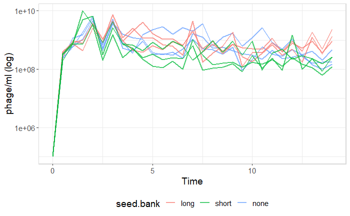

```r
d%>%
  filter(phage=="SPO1")%>%
    ggplot(aes(x=Time, y=phage.ml))+
      geom_line(aes(group=flask,color=seed.bank), size=1, alpha=0.7)+
      theme_bw()+
      panel_border()+
      scale_y_log10()+
      theme(legend.position = "bottom",
            text=element_text(size=14))+
      ylab("phage/ml (log)")+
      coord_cartesian(ylim = c(1e5, 1e10))
```

Here I will remove time 0, the input phage

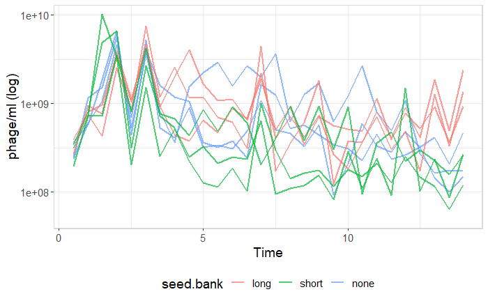

```r
d%>%
  filter(phage=="SPO1")%>%
  filter(Time!=0)%>%
    ggplot(aes(x=Time, y=phage.ml))+
      geom_line(aes(group=flask,color=seed.bank), size=1, alpha=0.7)+
      theme_bw()+
      panel_border()+
      scale_y_log10()+
      theme(legend.position = "bottom",
            text=element_text(size=14))+
      ylab("phage/ml (log)")+
      coord_cartesian(ylim = c(5e7, 1e10))
```

## Model selection

### ARMA covariance

This is a combined auto-regeressive model, AR(p) and moving average model, MA(q). I here take a model selection approach to choose these parameters (lowest AIC).

```r
# initalise empty table
pq.aic <- tibble(p=1, q=1,aic=1)%>%
  filter(p>1)

# Playing around with p&q I found the space in which the model convergence is limited
for(Q in c(0:2)){
  for (P in c(1:(10-2*Q))){

        #this fllowing combination does not work: "iteration limit reached without convergence"
    # if(P>=6 & Q==2) next

    cur.model <-
        d.4stat%>%
      filter(Time!=0)%>%
      filter(phage=="SPO1")%>%
  # looking only at total cells (cell.ml)
    lme(phage.ml ~ seed.bank * time.fct , random = ~1|flask,
            correlation = corARMA(form = ~ Time | flask, p=P,q=Q),
            data = .)

    pq.aic <-
      tibble(p=P, q=Q,aic=AIC(cur.model))%>%
      bind_rows(pq.aic,.)

  }
}

pq.aic%>%arrange(aic)
```

| p | q | aic |
| --- | --- | --- |
| 1 | 0 | 7633.930 |
| 2 | 1 | 7634.983 |
| 2 | 0 | 7635.364 |
| 1 | 1 | 7635.639 |
| 3 | 0 | 7636.253 |
| 3 | 1 | 7636.846 |
| 1 | 2 | 7637.038 |
| 2 | 2 | 7637.298 |
| 4 | 0 | 7637.700 |
| 4 | 1 | 7638.783 |

[output cut: 14 more lines]

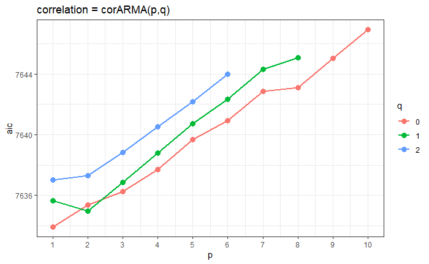

```r
pq.aic%>%
  mutate(q=as.character(q))%>%
  ggplot(aes(p,aic))+
  geom_line(aes(color=q),size=1)+
  geom_point(aes(color=q),size=3)+
  theme_bw()+
  scale_x_continuous(breaks = 1:10)+
  ggtitle("correlation = corARMA(p,q)")
```

```r
NA
NA
```

I will test the best 5 models against AR1,

### compare AR1 with ARMA

```r
l.rm <- list()

pq.best <- pq.aic%>%
  slice_min( order_by=aic,n=5)

for (i in 1:nrow(pq.best)){
  l.rm[[i]] <-
    d.4stat%>%
    filter(Time!=0)%>%
    filter(phage=="SPO1")%>%
  # looking only at phages (phage.ml)
    lme(phage.ml ~ seed.bank * time.fct , random = ~1|flask,
            correlation = corARMA(form = ~ 1 | flask,
                                  p=pq.best$p[i],q=pq.best$q[i]),
            data = .)

}


# add corAR1 to list
l.rm[[i+1]] <-
  d.4stat%>%
  filter(phage=="SPO1")%>%
  filter(Time!=0)%>%
 # looking only at phages (phage.ml)
    lme(phage.ml ~ seed.bank * time.fct , random = ~1|flask,
            correlation = corAR1(form = ~ 1 | flask),
            data = .)


# get list order by AIC
aic.l <- sapply(l.rm,AIC)%>%
  sort.list()


# compare models by AIC order
anova.lme(l.rm[[aic.l[6]]],
          l.rm[[aic.l[5]]],
          l.rm[[aic.l[4]]],
          l.rm[[aic.l[3]]],
          l.rm[[aic.l[2]]],
          l.rm[[aic.l[1]]])
```

|  | Model | df | AIC | BIC | logLik | Test | L.Ratio | p-value |
| --- | --- | --- | --- | --- | --- | --- | --- | --- |
| l.rm[[aic.l[6]]] | 1 | 89 | 7636.253 | 7914.286 | -3729.127 |  |  |  |
| l.rm[[aic.l[5]]] | 2 | 88 | 7635.639 | 7910.547 | -3729.819 | 1 vs 2 | 1.385239 | 0.2392 |
| l.rm[[aic.l[4]]] | 3 | 88 | 7635.364 | 7910.273 | -3729.682 |  |  |  |
| l.rm[[aic.l[3]]] | 4 | 89 | 7634.983 | 7913.016 | -3728.491 | 3 vs 4 | 2.381338 | 0.1228 |
| l.rm[[aic.l[2]]] | 5 | 87 | 7633.930 | 7905.715 | -3729.965 | 4 vs 5 | 2.947403 | 0.2291 |
| l.rm[[aic.l[1]]] | 6 | 87 | 7633.930 | 7905.715 | -3729.965 |  |  |  |

All models are comparable. There are 2 model with lowest DF, models 1 and 2. They are actually the same model: model 1 has P=1, Q=0, which is a coAR1 model.

```r
getCall(l.rm[[aic.l[1]]])
```

```
lme.formula(fixed = phage.ml ~ seed.bank * time.fct, data = .,
    random = ~1 | flask, correlation = corARMA(form = ~1 | flask,
        p = pq.best$p[i], q = pq.best$q[i]))
```

```r
getCall(l.rm[[aic.l[2]]])
```

```
lme.formula(fixed = phage.ml ~ seed.bank * time.fct, data = .,
    random = ~1 | flask, correlation = corAR1(form = ~1 | flask))
```

```r
#display best model results
getCall(l.rm[[aic.l[2]]])
```

```
lme.formula(fixed = phage.ml ~ seed.bank * time.fct, data = .,
    random = ~1 | flask, correlation = corAR1(form = ~1 | flask))
```

```r
  anova(l.rm[[aic.l[2]]])
```

|  | numDF | denDF | F-value | p-value |
| --- | --- | --- | --- | --- |
| (Intercept) | 1 | 162 | 135.03042 | <.0001 |
| seed.bank | 2 | 6 | 1.75273 | 0.2515 |
| time.fct | 27 | 162 | 15.23967 | <.0001 |
| seed.bank:time.fct | 54 | 162 | 2.33064 | <.0001 |

How sensetive would the result be to model selected?

```r
tmp <- map(l.rm, anova.lme)
tmp1 <- map(l.rm, getCall)

for(i in 1:6){
  print(tmp1[[i]])
  if(i<6) print(paste("p=",pq.best$p[i],"q=",pq.best$q[i]))

  print(tmp[[i]])
}
```

```
lme.formula(fixed = phage.ml ~ seed.bank * time.fct, data = .,
    random = ~1 | flask, correlation = corARMA(form = ~1 | flask,
        p = pq.best$p[i], q = pq.best$q[i]))
[1] "p= 1 q= 0"
```

|  | numDF | denDF | F-value | p-value |
| --- | --- | --- | --- | --- |
| (Intercept) | 1 | 162 | 135.03042 | <.0001 |
| seed.bank | 2 | 6 | 1.75273 | 0.2515 |
| time.fct | 27 | 162 | 15.23967 | <.0001 |
| seed.bank:time.fct | 54 | 162 | 2.33064 | <.0001 |

```
lme.formula(fixed = phage.ml ~ seed.bank * time.fct, data = .,
    random = ~1 | flask, correlation = corARMA(form = ~1 | flask,
        p = pq.best$p[i], q = pq.best$q[i]))
[1] "p= 2 q= 1"
```

|  | numDF | denDF | F-value | p-value |
| --- | --- | --- | --- | --- |
| (Intercept) | 1 | 162 | 136.33545 | <.0001 |
| seed.bank | 2 | 6 | 1.81873 | 0.2413 |
| time.fct | 27 | 162 | 14.77177 | <.0001 |
| seed.bank:time.fct | 54 | 162 | 2.29824 | <.0001 |

```
lme.formula(fixed = phage.ml ~ seed.bank * time.fct, data = .,
    random = ~1 | flask, correlation = corARMA(form = ~1 | flask,
        p = pq.best$p[i], q = pq.best$q[i]))
[1] "p= 2 q= 0"
```

|  | numDF | denDF | F-value | p-value |
| --- | --- | --- | --- | --- |
| (Intercept) | 1 | 162 | 135.69597 | <.0001 |
| seed.bank | 2 | 6 | 1.77674 | 0.2477 |
| time.fct | 27 | 162 | 14.59809 | <.0001 |
| seed.bank:time.fct | 54 | 162 | 2.32224 | <.0001 |

```
lme.formula(fixed = phage.ml ~ seed.bank * time.fct, data = .,
    random = ~1 | flask, correlation = corARMA(form = ~1 | flask,
        p = pq.best$p[i], q = pq.best$q[i]))
[1] "p= 1 q= 1"
```

|  | numDF | denDF | F-value | p-value |
| --- | --- | --- | --- | --- |
| (Intercept) | 1 | 162 | 135.84400 | <.0001 |
| seed.bank | 2 | 6 | 1.75031 | 0.2519 |
| time.fct | 27 | 162 | 14.83000 | <.0001 |
| seed.bank:time.fct | 54 | 162 | 2.32773 | <.0001 |

```
lme.formula(fixed = phage.ml ~ seed.bank * time.fct, data = .,
    random = ~1 | flask, correlation = corARMA(form = ~1 | flask,
        p = pq.best$p[i], q = pq.best$q[i]))
[1] "p= 3 q= 0"
```

|  | numDF | denDF | F-value | p-value |
| --- | --- | --- | --- | --- |
| (Intercept) | 1 | 162 | 132.91744 | <.0001 |
| seed.bank | 2 | 6 | 1.90994 | 0.2281 |
| time.fct | 27 | 162 | 15.34508 | <.0001 |
| seed.bank:time.fct | 54 | 162 | 2.28572 | <.0001 |

```
lme.formula(fixed = phage.ml ~ seed.bank * time.fct, data = .,
    random = ~1 | flask, correlation = corAR1(form = ~1 | flask))
```

|  | numDF | denDF | F-value | p-value |
| --- | --- | --- | --- | --- |
| (Intercept) | 1 | 162 | 135.03042 | <.0001 |
| seed.bank | 2 | 6 | 1.75273 | 0.2515 |
| time.fct | 27 | 162 | 15.23967 | <.0001 |
| seed.bank:time.fct | 54 | 162 | 2.33064 | <.0001 |

All models show the same story: Seed bank X time significant for phage.

=================

# spore density

=================

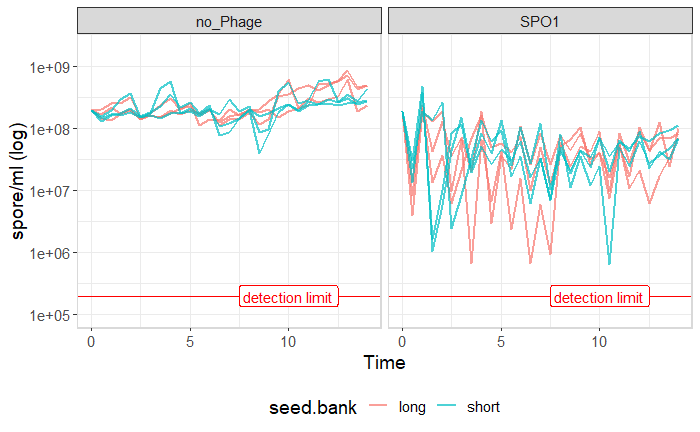

```r
d%>%
  filter(host=="WT")%>%
       ggplot(aes(x=Time, y=spore.ml))+
      geom_line(aes(group=flask,color=seed.bank), size=1, alpha=0.7)+
  geom_hline(yintercept = detection.limit, color="red")+
  geom_label(label="detection limit", x=10, y=log10(detection.limit), color="red")+
      facet_wrap(~phage)+
      theme_bw()+
      panel_border()+
      scale_y_log10()+
      theme(legend.position = "bottom",
            text=element_text(size=14))+
      ylab("spore/ml (log)")+
      coord_cartesian(ylim = c(1e5, 2e9))
```

All points usable.

## Model selection

### ARMA covariance

This is a combined auto-regeressive model, AR(p) and moving average model, MA(q). I here take a model selection approach to choose these parameters (lowest AIC).

```r
# initalise empty table
pq.aic <- tibble(p=1, q=1,aic=1)%>%
  filter(p>1)

# Playing around with p&q I found the space in which the model convergence is limited
for(Q in c(0:2)){
  for (P in c(1:(10-2*Q))){

        #this fllowing combination does not work: "iteration limit reached without convergence"
    if(P>=3 & Q==2) next

    cur.model <-
        d.4stat%>%
      filter(host=="WT")%>%
  # looking only at total cells (cell.ml)
    lme(spore.ml ~ phage*seed.bank * time.fct , random = ~1|flask,
            correlation = corARMA(form = ~ Time | flask, p=P,q=Q),
            data = .)

    pq.aic <-
      tibble(p=P, q=Q,aic=AIC(cur.model))%>%
      bind_rows(pq.aic,.)

  }
}

pq.aic%>%arrange(aic)
```

| p | q | aic |
| --- | --- | --- |
| 1 | 0 | 9341.917 |
| 3 | 0 | 9342.208 |
| 1 | 2 | 9342.705 |
| 1 | 1 | 9342.755 |
| 2 | 0 | 9343.203 |
| 4 | 0 | 9343.527 |
| 3 | 1 | 9343.834 |
| 2 | 1 | 9344.386 |
| 2 | 2 | 9344.705 |
| 4 | 1 | 9345.045 |

[output cut: 10 more lines]

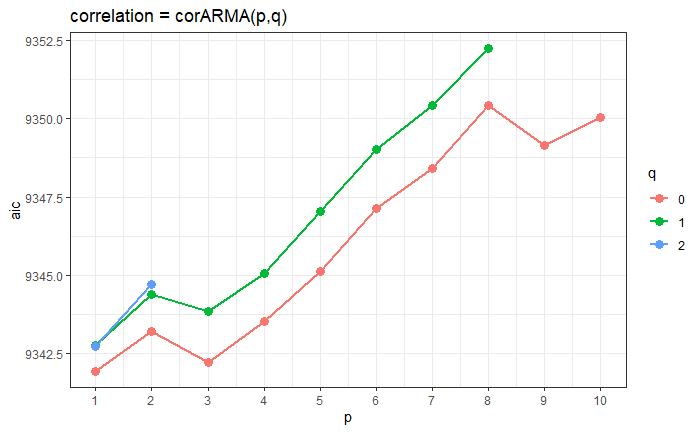

```r
pq.aic%>%
  mutate(q=as.character(q))%>%
  ggplot(aes(p,aic))+
  geom_line(aes(color=q),size=1)+
  geom_point(aes(color=q),size=3)+
  theme_bw()+
  scale_x_continuous(breaks = 1:10)+
  ggtitle("correlation = corARMA(p,q)")
```

```r
NA
NA
```

I will test the best 5 models against AR1,

### compare AR1 with ARMA

```r
l.rm <- list()

pq.best <- pq.aic%>%
  slice_min( order_by=aic,n=5)

for (i in 1:nrow(pq.best)){
  l.rm[[i]] <-
        d.4stat%>%
      filter(host=="WT")%>%
  # looking only at total spore (spore.ml)
    lme(spore.ml ~ phage*seed.bank * time.fct , random = ~1|flask,
        correlation = corARMA(form = ~ 1 | flask,
                              p=pq.best$p[i],q=pq.best$q[i]),
            data = .)

}


# add corAR1 to list
l.rm[[i+1]] <-
        d.4stat%>%
      filter(host=="WT")%>%
  # looking only at total spore (spore.ml)
    lme(spore.ml ~ phage*seed.bank * time.fct , random = ~1|flask,
            correlation = corAR1(form = ~ 1 | flask),
            data = .)


# get list order by AIC
aic.l <- sapply(l.rm,AIC)%>%
  sort.list()


# compare models by AIC order
anova.lme(l.rm[[aic.l[6]]],
          l.rm[[aic.l[5]]],
          l.rm[[aic.l[4]]],
          l.rm[[aic.l[3]]],
          l.rm[[aic.l[2]]],
          l.rm[[aic.l[1]]])
```

|  | Model | df | AIC | BIC | logLik | Test | L.Ratio | p-value |
| --- | --- | --- | --- | --- | --- | --- | --- | --- |
| l.rm[[aic.l[6]]] | 1 | 120 | 9343.203 | 9756.811 | -4551.601 |  |  |  |
| l.rm[[aic.l[5]]] | 2 | 120 | 9342.755 | 9756.364 | -4551.378 |  |  |  |
| l.rm[[aic.l[4]]] | 3 | 121 | 9342.705 | 9759.760 | -4550.352 | 2 vs 3 | 2.050778 | 0.1521 |
| l.rm[[aic.l[3]]] | 4 | 121 | 9342.208 | 9759.263 | -4550.104 |  |  |  |
| l.rm[[aic.l[2]]] | 5 | 119 | 9341.917 | 9752.079 | -4551.958 | 4 vs 5 | 3.709016 | 0.1565 |
| l.rm[[aic.l[1]]] | 6 | 119 | 9341.917 | 9752.079 | -4551.958 |  |  |  |

All models are comparable. There are 2 model with lowest DF, models 1 and 2. They are actually the same model: model 1 has P=1, Q=0, which is a coAR1 model.

```r
getCall(l.rm[[aic.l[1]]])
```

```
lme.formula(fixed = spore.ml ~ phage * seed.bank * time.fct,
    data = ., random = ~1 | flask, correlation = corARMA(form = ~1 |
        flask, p = pq.best$p[i], q = pq.best$q[i]))
```

```r
getCall(l.rm[[aic.l[2]]])
```

```
lme.formula(fixed = spore.ml ~ phage * seed.bank * time.fct,
    data = ., random = ~1 | flask, correlation = corAR1(form = ~1 |
        flask))
```

```r
#display best model results
getCall(l.rm[[aic.l[2]]])
```

```
lme.formula(fixed = spore.ml ~ phage * seed.bank * time.fct,
    data = ., random = ~1 | flask, correlation = corAR1(form = ~1 |
        flask))
```

```r
  anova.lme(l.rm[[aic.l[2]]])
```

|  | numDF | denDF | F-value | p-value |
| --- | --- | --- | --- | --- |
| (Intercept) | 1 | 224 | 649.9221 | <.0001 |
| phage | 1 | 8 | 215.1737 | <.0001 |
| seed.bank | 1 | 8 | 1.5629 | 0.2466 |
| time.fct | 28 | 224 | 9.8417 | <.0001 |
| phage:seed.bank | 1 | 8 | 2.6482 | 0.1423 |
| phage:time.fct | 28 | 224 | 6.1813 | <.0001 |
| seed.bank:time.fct | 28 | 224 | 1.5618 | 0.0415 |
| phage:seed.bank:time.fct | 28 | 224 | 1.6285 | 0.0287 |

**There is significant effect of interaction of phage, seed.bank and time on spore population density.**

How sensetive would the result be to model selected?

```r
tmp <- map(l.rm, anova.lme)
tmp1 <- map(l.rm, getCall)

for(i in 1:6){
  print(tmp1[[i]])
  if(i<6) print(paste("p=",pq.best$p[i],"q=",pq.best$q[i]))

  print(tmp[[i]])
}
```

```
lme.formula(fixed = spore.ml ~ phage * seed.bank * time.fct,
    data = ., random = ~1 | flask, correlation = corARMA(form = ~1 |
        flask, p = pq.best$p[i], q = pq.best$q[i]))
[1] "p= 1 q= 0"
```

|  | numDF | denDF | F-value | p-value |
| --- | --- | --- | --- | --- |
| (Intercept) | 1 | 224 | 649.9221 | <.0001 |
| phage | 1 | 8 | 215.1737 | <.0001 |
| seed.bank | 1 | 8 | 1.5629 | 0.2466 |
| time.fct | 28 | 224 | 9.8417 | <.0001 |
| phage:seed.bank | 1 | 8 | 2.6482 | 0.1423 |
| phage:time.fct | 28 | 224 | 6.1813 | <.0001 |
| seed.bank:time.fct | 28 | 224 | 1.5618 | 0.0415 |
| phage:seed.bank:time.fct | 28 | 224 | 1.6285 | 0.0287 |

```
lme.formula(fixed = spore.ml ~ phage * seed.bank * time.fct,
    data = ., random = ~1 | flask, correlation = corARMA(form = ~1 |
        flask, p = pq.best$p[i], q = pq.best$q[i]))
[1] "p= 3 q= 0"
```

|  | numDF | denDF | F-value | p-value |
| --- | --- | --- | --- | --- |
| (Intercept) | 1 | 224 | 599.3407 | <.0001 |
| phage | 1 | 8 | 192.6699 | <.0001 |
| seed.bank | 1 | 8 | 1.6082 | 0.2404 |
| time.fct | 28 | 224 | 11.6597 | <.0001 |
| phage:seed.bank | 1 | 8 | 2.8409 | 0.1304 |
| phage:time.fct | 28 | 224 | 6.4180 | <.0001 |
| seed.bank:time.fct | 28 | 224 | 1.5197 | 0.0519 |
| phage:seed.bank:time.fct | 28 | 224 | 1.5144 | 0.0534 |

```
lme.formula(fixed = spore.ml ~ phage * seed.bank * time.fct,
    data = ., random = ~1 | flask, correlation = corARMA(form = ~1 |
        flask, p = pq.best$p[i], q = pq.best$q[i]))
[1] "p= 1 q= 2"
```

|  | numDF | denDF | F-value | p-value |
| --- | --- | --- | --- | --- |
| (Intercept) | 1 | 224 | 559.8122 | <.0001 |
| phage | 1 | 8 | 179.7807 | <.0001 |
| seed.bank | 1 | 8 | 1.5388 | 0.2499 |
| time.fct | 28 | 224 | 11.3641 | <.0001 |
| phage:seed.bank | 1 | 8 | 2.6910 | 0.1395 |
| phage:time.fct | 28 | 224 | 6.3686 | <.0001 |
| seed.bank:time.fct | 28 | 224 | 1.5206 | 0.0516 |
| phage:seed.bank:time.fct | 28 | 224 | 1.5412 | 0.0463 |

```
lme.formula(fixed = spore.ml ~ phage * seed.bank * time.fct,
    data = ., random = ~1 | flask, correlation = corARMA(form = ~1 |
        flask, p = pq.best$p[i], q = pq.best$q[i]))
[1] "p= 1 q= 1"
```

|  | numDF | denDF | F-value | p-value |
| --- | --- | --- | --- | --- |
| (Intercept) | 1 | 224 | 741.0462 | <.0001 |
| phage | 1 | 8 | 245.8277 | <.0001 |
| seed.bank | 1 | 8 | 1.7769 | 0.2192 |
| time.fct | 28 | 224 | 11.0839 | <.0001 |
| phage:seed.bank | 1 | 8 | 3.0305 | 0.1199 |
| phage:time.fct | 28 | 224 | 6.6540 | <.0001 |
| seed.bank:time.fct | 28 | 224 | 1.5592 | 0.0420 |
| phage:seed.bank:time.fct | 28 | 224 | 1.5762 | 0.0383 |

```
lme.formula(fixed = spore.ml ~ phage * seed.bank * time.fct,
    data = ., random = ~1 | flask, correlation = corARMA(form = ~1 |
        flask, p = pq.best$p[i], q = pq.best$q[i]))
[1] "p= 2 q= 0"
```

|  | numDF | denDF | F-value | p-value |
| --- | --- | --- | --- | --- |
| (Intercept) | 1 | 224 | 716.3557 | <.0001 |
| phage | 1 | 8 | 238.0012 | <.0001 |
| seed.bank | 1 | 8 | 1.7061 | 0.2278 |
| time.fct | 28 | 224 | 10.5568 | <.0001 |
| phage:seed.bank | 1 | 8 | 2.8927 | 0.1274 |
| phage:time.fct | 28 | 224 | 6.4935 | <.0001 |
| seed.bank:time.fct | 28 | 224 | 1.5616 | 0.0415 |
| phage:seed.bank:time.fct | 28 | 224 | 1.5993 | 0.0338 |

```
lme.formula(fixed = spore.ml ~ phage * seed.bank * time.fct,
    data = ., random = ~1 | flask, correlation = corAR1(form = ~1 |
        flask))
```

|  | numDF | denDF | F-value | p-value |
| --- | --- | --- | --- | --- |
| (Intercept) | 1 | 224 | 649.9221 | <.0001 |
| phage | 1 | 8 | 215.1737 | <.0001 |
| seed.bank | 1 | 8 | 1.5629 | 0.2466 |
| time.fct | 28 | 224 | 9.8417 | <.0001 |
| phage:seed.bank | 1 | 8 | 2.6482 | 0.1423 |
| phage:time.fct | 28 | 224 | 6.1813 | <.0001 |
| seed.bank:time.fct | 28 | 224 | 1.5618 | 0.0415 |
| phage:seed.bank:time.fct | 28 | 224 | 1.6285 | 0.0287 |

The phage:seed-bank:time interaction is hovering closely below 0.05, with 1 model (ARMA: p=3,q=0) having it above 0.05 at 0.0534.

=================

# percent spore

=================

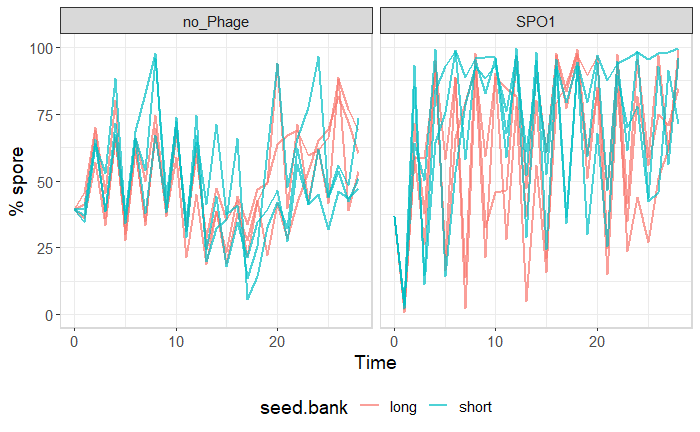

```r
d.4stat <- d.4stat%>%
  mutate(perc.spore=100*spore.ml/cell.ml)

d.4stat%>%
  filter(host=="WT")%>%
    ggplot(aes(x=Time, y=perc.spore))+
    geom_line(aes(group=flask,color=seed.bank), size=1, alpha=0.7)+
    theme_bw()+
    panel_border()+
  facet_wrap(~phage)+
  theme(legend.position = "bottom",
            text=element_text(size=14))+
  ylab("% spore")+
  ylim(0,100)
```

All points usable.

## Model selection

### ARMA covariance

This is a combined auto-regeressive model, AR(p) and moving average model, MA(q). I here take a model selection approach to choose these parameters (lowest AIC).

```r
# initalise empty table
pq.aic <- tibble(p=1, q=1,aic=1)%>%
  filter(p>1)

# Playing around with p&q I found the space in which the model convergence is limited
for(Q in c(0:2)){
  for (P in c(1:(10-2*Q))){

        #this fllowing combination does not work: "iteration limit reached without convergence"
    if(P>=10 & Q==0) next
    if(P>=4 & Q==2) next

    cur.model <-
        d.4stat%>%
      filter(host=="WT")%>%
  # looking only at total cells (cell.ml)
    lme(perc.spore ~ phage*seed.bank * time.fct , random = ~1|flask,
            correlation = corARMA(form = ~ Time | flask, p=P,q=Q),
            data = .)

    pq.aic <-
      tibble(p=P, q=Q,aic=AIC(cur.model))%>%
      bind_rows(pq.aic,.)

  }
}

pq.aic%>%arrange(aic)
```

| p | q | aic |
| --- | --- | --- |
| 5 | 0 | 2261.910 |
| 7 | 0 | 2261.941 |
| 6 | 0 | 2261.941 |
| 1 | 1 | 2261.969 |
| 4 | 1 | 2262.160 |
| 2 | 0 | 2262.498 |
| 2 | 2 | 2262.537 |
| 8 | 0 | 2262.596 |
| 4 | 0 | 2262.674 |
| 2 | 1 | 2262.726 |

[output cut: 10 more lines]

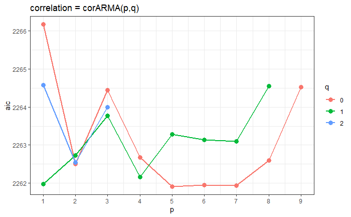

```r
pq.aic%>%
  mutate(q=as.character(q))%>%
  ggplot(aes(p,aic))+
  geom_line(aes(color=q),size=1)+
  geom_point(aes(color=q),size=3)+
  theme_bw()+
  scale_x_continuous(breaks = 1:10)+
  ggtitle("correlation = corARMA(p,q)")
```

```r
NA
NA
```

I will test the best 5 models against AR1,

### compare AR1 with ARMA

```r
l.rm <- list()

pq.best <- pq.aic%>%
  slice_min( order_by=aic,n=5)

for (i in 1:nrow(pq.best)){
  l.rm[[i]] <-
        d.4stat%>%
      filter(host=="WT")%>%
  # looking only at total spore (spore.ml)
    lme(perc.spore ~ phage*seed.bank * time.fct , random = ~1|flask,
        correlation = corARMA(form = ~ Time | flask,
                              p=pq.best$p[i],q=pq.best$q[i]),
            data = .)

}


# add corAR1 to list
l.rm[[i+1]] <-
        d.4stat%>%
      filter(host=="WT")%>%
  # looking only at total spore (spore.ml)
    lme(perc.spore ~ phage*seed.bank * time.fct , random = ~1|flask,
            correlation = corAR1(form = ~ Time | flask),
            data = .)


# get list order by AIC
aic.l <- sapply(l.rm,AIC)%>%
  sort.list()


# compare models by AIC order
anova.lme(l.rm[[aic.l[6]]],
          l.rm[[aic.l[5]]],
          l.rm[[aic.l[4]]],
          l.rm[[aic.l[3]]],
          l.rm[[aic.l[2]]],
          l.rm[[aic.l[1]]])
```

|  | Model | df | AIC | BIC | logLik | Test | L.Ratio | p-value |
| --- | --- | --- | --- | --- | --- | --- | --- | --- |
| l.rm[[aic.l[6]]] | 1 | 119 | 2266.175 | 2676.337 | -1014.088 |  |  |  |
| l.rm[[aic.l[5]]] | 2 | 123 | 2262.160 | 2686.109 | -1008.080 | 1 vs 2 | 12.015067 | 0.0172 |
| l.rm[[aic.l[4]]] | 3 | 120 | 2261.969 | 2675.578 | -1010.985 | 2 vs 3 | 5.808984 | 0.1213 |
| l.rm[[aic.l[3]]] | 4 | 124 | 2261.941 | 2689.337 | -1006.971 | 3 vs 4 | 8.027902 | 0.0906 |
| l.rm[[aic.l[2]]] | 5 | 125 | 2261.941 | 2692.783 | -1005.971 | 4 vs 5 | 2.000375 | 0.1573 |
| l.rm[[aic.l[1]]] | 6 | 123 | 2261.910 | 2685.859 | -1007.955 | 5 vs 6 | 3.969437 | 0.1374 |

```r
#display best model results
getCall(l.rm[[aic.l[6]]])
```

```
lme.formula(fixed = perc.spore ~ phage * seed.bank * time.fct,
    data = ., random = ~1 | flask, correlation = corAR1(form = ~Time |
        flask))
```

```r
  anova.lme(l.rm[[aic.l[6]]])
```

|  | numDF | denDF | F-value | p-value |
| --- | --- | --- | --- | --- |
| (Intercept) | 1 | 224 | 2985.6355 | <.0001 |
| phage | 1 | 8 | 64.8424 | <.0001 |
| seed.bank | 1 | 8 | 4.4422 | 0.0681 |
| time.fct | 28 | 224 | 23.5086 | <.0001 |
| phage:seed.bank | 1 | 8 | 5.5930 | 0.0456 |
| phage:time.fct | 28 | 224 | 4.5134 | <.0001 |
| seed.bank:time.fct | 28 | 224 | 1.7647 | 0.0131 |
| phage:seed.bank:time.fct | 28 | 224 | 1.3838 | 0.1030 |

**There is a significant interaction of all 2-way interactions on percent spore in the population, but not for the 3-way.**

How sensetive would the result be to model selected?

```r
tmp <- map(l.rm, anova.lme)
tmp1 <- map(l.rm, getCall)

for(i in 1:6){
  print(tmp1[[i]])
  if(i<6) print(paste("p=",pq.best$p[i],"q=",pq.best$q[i]))

  print(tmp[[i]])
}
```

```
lme.formula(fixed = perc.spore ~ phage * seed.bank * time.fct,
    data = ., random = ~1 | flask, correlation = corARMA(form = ~Time |
        flask, p = pq.best$p[i], q = pq.best$q[i]))
[1] "p= 5 q= 0"
```

|  | numDF | denDF | F-value | p-value |
| --- | --- | --- | --- | --- |
| (Intercept) | 1 | 224 | 2197.5679 | <.0001 |
| phage | 1 | 8 | 45.1324 | 0.0001 |
| seed.bank | 1 | 8 | 2.9129 | 0.1263 |
| time.fct | 28 | 224 | 14.0133 | <.0001 |
| phage:seed.bank | 1 | 8 | 4.3411 | 0.0707 |
| phage:time.fct | 28 | 224 | 4.0904 | <.0001 |
| seed.bank:time.fct | 28 | 224 | 1.8550 | 0.0076 |
| phage:seed.bank:time.fct | 28 | 224 | 1.3908 | 0.0996 |

```
lme.formula(fixed = perc.spore ~ phage * seed.bank * time.fct,
    data = ., random = ~1 | flask, correlation = corARMA(form = ~Time |
        flask, p = pq.best$p[i], q = pq.best$q[i]))
[1] "p= 7 q= 0"
```

|  | numDF | denDF | F-value | p-value |
| --- | --- | --- | --- | --- |
| (Intercept) | 1 | 224 | 1618.5024 | <.0001 |
| phage | 1 | 8 | 29.2216 | 0.0006 |
| seed.bank | 1 | 8 | 1.9690 | 0.1982 |
| time.fct | 28 | 224 | 14.5710 | <.0001 |
| phage:seed.bank | 1 | 8 | 3.4029 | 0.1023 |
| phage:time.fct | 28 | 224 | 4.2339 | <.0001 |
| seed.bank:time.fct | 28 | 224 | 1.9523 | 0.0042 |
| phage:seed.bank:time.fct | 28 | 224 | 1.5327 | 0.0484 |

```
lme.formula(fixed = perc.spore ~ phage * seed.bank * time.fct,
    data = ., random = ~1 | flask, correlation = corARMA(form = ~Time |
        flask, p = pq.best$p[i], q = pq.best$q[i]))
[1] "p= 6 q= 0"
```

|  | numDF | denDF | F-value | p-value |
| --- | --- | --- | --- | --- |
| (Intercept) | 1 | 224 | 1860.3915 | <.0001 |
| phage | 1 | 8 | 35.8375 | 0.0003 |
| seed.bank | 1 | 8 | 2.4071 | 0.1594 |
| time.fct | 28 | 224 | 13.0954 | <.0001 |
| phage:seed.bank | 1 | 8 | 3.8632 | 0.0849 |
| phage:time.fct | 28 | 224 | 4.0668 | <.0001 |
| seed.bank:time.fct | 28 | 224 | 1.9683 | 0.0038 |
| phage:seed.bank:time.fct | 28 | 224 | 1.5161 | 0.0529 |

```
lme.formula(fixed = perc.spore ~ phage * seed.bank * time.fct,
    data = ., random = ~1 | flask, correlation = corARMA(form = ~Time |
        flask, p = pq.best$p[i], q = pq.best$q[i]))
[1] "p= 1 q= 1"
```

|  | numDF | denDF | F-value | p-value |
| --- | --- | --- | --- | --- |
| (Intercept) | 1 | 224 | 1894.3232 | <.0001 |
| phage | 1 | 8 | 36.6286 | 0.0003 |
| seed.bank | 1 | 8 | 2.2923 | 0.1685 |
| time.fct | 28 | 224 | 20.6422 | <.0001 |
| phage:seed.bank | 1 | 8 | 3.7296 | 0.0896 |
| phage:time.fct | 28 | 224 | 4.2927 | <.0001 |
| seed.bank:time.fct | 28 | 224 | 1.8016 | 0.0105 |
| phage:seed.bank:time.fct | 28 | 224 | 1.3382 | 0.1277 |

```
lme.formula(fixed = perc.spore ~ phage * seed.bank * time.fct,
    data = ., random = ~1 | flask, correlation = corARMA(form = ~Time |
        flask, p = pq.best$p[i], q = pq.best$q[i]))
[1] "p= 4 q= 1"
```

|  | numDF | denDF | F-value | p-value |
| --- | --- | --- | --- | --- |
| (Intercept) | 1 | 224 | 1909.8607 | <.0001 |
| phage | 1 | 8 | 37.1713 | 0.0003 |
| seed.bank | 1 | 8 | 2.3573 | 0.1632 |
| time.fct | 28 | 224 | 13.6336 | <.0001 |
| phage:seed.bank | 1 | 8 | 3.8577 | 0.0851 |
| phage:time.fct | 28 | 224 | 4.0520 | <.0001 |
| seed.bank:time.fct | 28 | 224 | 1.9043 | 0.0056 |
| phage:seed.bank:time.fct | 28 | 224 | 1.4151 | 0.0884 |

```
lme.formula(fixed = perc.spore ~ phage * seed.bank * time.fct,
    data = ., random = ~1 | flask, correlation = corAR1(form = ~Time |
        flask))
```

|  | numDF | denDF | F-value | p-value |
| --- | --- | --- | --- | --- |
| (Intercept) | 1 | 224 | 2985.6355 | <.0001 |
| phage | 1 | 8 | 64.8424 | <.0001 |
| seed.bank | 1 | 8 | 4.4422 | 0.0681 |
| time.fct | 28 | 224 | 23.5086 | <.0001 |
| phage:seed.bank | 1 | 8 | 5.5930 | 0.0456 |
| phage:time.fct | 28 | 224 | 4.5134 | <.0001 |
| seed.bank:time.fct | 28 | 224 | 1.7647 | 0.0131 |
| phage:seed.bank:time.fct | 28 | 224 | 1.3838 | 0.1030 |

One of the models (no. 2) has the 3-way intercaction significant, and all models but the AR1 have the seed-bank:phage interaction as non significant.

=================

# Veg cells

=================

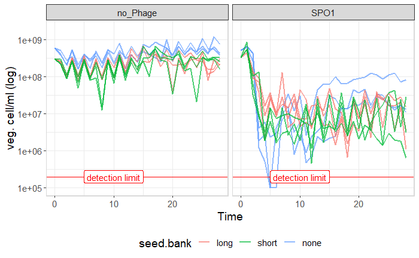

```r
d.4stat%>%
    ggplot(aes(x=Time, y=veg.ml))+
      geom_line(aes(group=flask,color=seed.bank), size=1, alpha=0.7)+
  geom_hline(yintercept = detection.limit, color="red")+
  geom_label(label="detection limit", x=10, y=log10(detection.limit), color="red")+
      facet_wrap(~phage)+
      theme_bw()+
      panel_border()+
      scale_y_log10()+
      theme(legend.position = "bottom",
            text=element_text(size=14))+
      ylab("veg. cell/ml (log)")+
      coord_cartesian(ylim = c(1e5, 2e9))
```

All points usable.

## Model selection

### ARMA covariance

This is a combined auto-regeressive model, AR(p) and moving average model, MA(q). I here take a model selection approach to choose these parameters (lowest AIC).

| p | q | aic |
| --- | --- | --- |
| 6 | 1 | 14128.82 |
| 6 | 0 | 14129.39 |
| 6 | 2 | 14130.64 |
| 7 | 1 | 14130.70 |
| 7 | 0 | 14130.72 |
| 5 | 1 | 14130.94 |
| 8 | 0 | 14131.31 |
| 5 | 0 | 14131.89 |
| 4 | 1 | 14132.51 |
| 5 | 2 | 14132.61 |

[output cut: 8 more lines]

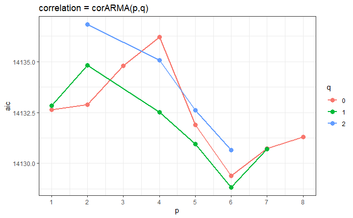

```r
pq.aic%>%arrange(aic)


pq.aic%>%
  mutate(q=as.character(q))%>%
  ggplot(aes(p,aic))+
  geom_line(aes(color=q),size=1)+
  geom_point(aes(color=q),size=3)+
  theme_bw()+
  scale_x_continuous(breaks = 1:10)+
  ggtitle("correlation = corARMA(p,q)")
```

I will test the best 5 models against AR1,

### compare AR1 with ARMA

```r
l.rm <- list()

pq.best <- pq.aic%>%
  slice_min( order_by=aic,n=5)

for (i in 1:nrow(pq.best)){
  l.rm[[i]] <-
        d.4stat%>%
  # looking only at veg cells (veg.ml)
    lme(veg.ml ~ phage*seed.bank * time.fct , random = ~1|flask,
        correlation = corARMA(form = ~ Time | flask,
                              p=pq.best$p[i],q=pq.best$q[i]),
            data = .)

}


# add corAR1 to list
l.rm[[i+1]] <-
        d.4stat%>%
  # looking only at veg cells (veg.ml)
    lme(veg.ml ~ phage*seed.bank * time.fct , random = ~1|flask,
            correlation = corAR1(form = ~ Time | flask),
            data = .)


# get list order by AIC
aic.l <- sapply(l.rm,AIC)%>%
  sort.list()


# compare models by AIC order
anova.lme(l.rm[[aic.l[6]]],
          l.rm[[aic.l[5]]],
          l.rm[[aic.l[4]]],
          l.rm[[aic.l[3]]],
          l.rm[[aic.l[2]]],
          l.rm[[aic.l[1]]])
```

|  | Model | df | AIC | BIC | logLik | Test | L.Ratio | p-value |
| --- | --- | --- | --- | --- | --- | --- | --- | --- |
| l.rm[[aic.l[6]]] | 1 | 177 | 14132.63 | 14814.47 | -6889.314 |  |  |  |
| l.rm[[aic.l[5]]] | 2 | 183 | 14130.72 | 14835.67 | -6882.361 | 1 vs 2 | 13.906200 | 0.0307 |
| l.rm[[aic.l[4]]] | 3 | 184 | 14130.70 | 14839.50 | -6881.349 | 2 vs 3 | 2.022283 | 0.1550 |
| l.rm[[aic.l[3]]] | 4 | 184 | 14130.64 | 14839.45 | -6881.322 |  |  |  |
| l.rm[[aic.l[2]]] | 5 | 182 | 14129.39 | 14830.49 | -6882.694 | 4 vs 5 | 2.744335 | 0.2536 |
| l.rm[[aic.l[1]]] | 6 | 183 | 14128.82 | 14833.77 | -6881.409 | 5 vs 6 | 2.570991 | 0.1088 |

```r
#display best model results
getCall(l.rm[[aic.l[6]]])
```

```
lme.formula(fixed = veg.ml ~ phage * seed.bank * time.fct, data = .,
    random = ~1 | flask, correlation = corAR1(form = ~Time |
        flask))
```

```r
  anova.lme(l.rm[[aic.l[6]]])
```

|  | numDF | denDF | F-value | p-value |
| --- | --- | --- | --- | --- |
| (Intercept) | 1 | 336 | 928.7124 | <.0001 |
| phage | 1 | 12 | 430.4257 | <.0001 |
| seed.bank | 2 | 12 | 41.6490 | <.0001 |
| time.fct | 28 | 336 | 28.8061 | <.0001 |
| phage:seed.bank | 2 | 12 | 22.5238 | 1e-04 |
| phage:time.fct | 28 | 336 | 25.6113 | <.0001 |
| seed.bank:time.fct | 56 | 336 | 1.8997 | 3e-04 |
| phage:seed.bank:time.fct | 56 | 336 | 1.8374 | 6e-04 |

**There is significant effect of interaction of phage, seed.bank and time on veg population density.**

How sensetive would the result be to model selected?

```r
tmp <- map(l.rm, anova.lme)
tmp1 <- map(l.rm, getCall)

for(i in 1:6){
  print(tmp1[[i]])
  if(i<6) print(paste("p=",pq.best$p[i],"q=",pq.best$q[i]))

  print(tmp[[i]])
}
```

```
lme.formula(fixed = veg.ml ~ phage * seed.bank * time.fct, data = .,
    random = ~1 | flask, correlation = corARMA(form = ~Time |
        flask, p = pq.best$p[i], q = pq.best$q[i]))
[1] "p= 6 q= 1"
```

|  | numDF | denDF | F-value | p-value |
| --- | --- | --- | --- | --- |
| (Intercept) | 1 | 336 | 1091.2422 | <.0001 |
| phage | 1 | 12 | 444.5146 | <.0001 |
| seed.bank | 2 | 12 | 50.7101 | <.0001 |
| time.fct | 28 | 336 | 27.2134 | <.0001 |
| phage:seed.bank | 2 | 12 | 25.5272 | <.0001 |
| phage:time.fct | 28 | 336 | 22.6731 | <.0001 |
| seed.bank:time.fct | 56 | 336 | 2.0386 | 1e-04 |
| phage:seed.bank:time.fct | 56 | 336 | 1.8507 | 5e-04 |

```
lme.formula(fixed = veg.ml ~ phage * seed.bank * time.fct, data = .,
    random = ~1 | flask, correlation = corARMA(form = ~Time |
        flask, p = pq.best$p[i], q = pq.best$q[i]))
[1] "p= 6 q= 0"
```

|  | numDF | denDF | F-value | p-value |
| --- | --- | --- | --- | --- |
| (Intercept) | 1 | 336 | 1029.9903 | <.0001 |
| phage | 1 | 12 | 411.2374 | <.0001 |
| seed.bank | 2 | 12 | 48.4267 | <.0001 |
| time.fct | 28 | 336 | 33.2761 | <.0001 |
| phage:seed.bank | 2 | 12 | 24.1238 | 1e-04 |
| phage:time.fct | 28 | 336 | 26.4565 | <.0001 |
| seed.bank:time.fct | 56 | 336 | 2.0641 | <.0001 |
| phage:seed.bank:time.fct | 56 | 336 | 1.9741 | 1e-04 |

```
lme.formula(fixed = veg.ml ~ phage * seed.bank * time.fct, data = .,
    random = ~1 | flask, correlation = corARMA(form = ~Time |
        flask, p = pq.best$p[i], q = pq.best$q[i]))
[1] "p= 6 q= 2"
```

|  | numDF | denDF | F-value | p-value |
| --- | --- | --- | --- | --- |
| (Intercept) | 1 | 336 | 1060.2635 | <.0001 |
| phage | 1 | 12 | 428.5680 | <.0001 |
| seed.bank | 2 | 12 | 49.4192 | <.0001 |
| time.fct | 28 | 336 | 27.4213 | <.0001 |
| phage:seed.bank | 2 | 12 | 24.7961 | 1e-04 |
| phage:time.fct | 28 | 336 | 22.6728 | <.0001 |
| seed.bank:time.fct | 56 | 336 | 2.0534 | 1e-04 |
| phage:seed.bank:time.fct | 56 | 336 | 1.8552 | 5e-04 |

```
lme.formula(fixed = veg.ml ~ phage * seed.bank * time.fct, data = .,
    random = ~1 | flask, correlation = corARMA(form = ~Time |
        flask, p = pq.best$p[i], q = pq.best$q[i]))
[1] "p= 7 q= 1"
```

|  | numDF | denDF | F-value | p-value |
| --- | --- | --- | --- | --- |
| (Intercept) | 1 | 336 | 1072.5578 | <.0001 |
| phage | 1 | 12 | 434.7283 | <.0001 |
| seed.bank | 2 | 12 | 49.9178 | <.0001 |
| time.fct | 28 | 336 | 27.3305 | <.0001 |
| phage:seed.bank | 2 | 12 | 25.0733 | 1e-04 |
| phage:time.fct | 28 | 336 | 22.6629 | <.0001 |
| seed.bank:time.fct | 56 | 336 | 2.0485 | 1e-04 |
| phage:seed.bank:time.fct | 56 | 336 | 1.8525 | 5e-04 |

```
lme.formula(fixed = veg.ml ~ phage * seed.bank * time.fct, data = .,
    random = ~1 | flask, correlation = corARMA(form = ~Time |
        flask, p = pq.best$p[i], q = pq.best$q[i]))
[1] "p= 7 q= 0"
```

|  | numDF | denDF | F-value | p-value |
| --- | --- | --- | --- | --- |
| (Intercept) | 1 | 336 | 1075.8115 | <.0001 |
| phage | 1 | 12 | 433.7155 | <.0001 |
| seed.bank | 2 | 12 | 50.1959 | <.0001 |
| time.fct | 28 | 336 | 31.4893 | <.0001 |
| phage:seed.bank | 2 | 12 | 25.1202 | 1e-04 |
| phage:time.fct | 28 | 336 | 25.3393 | <.0001 |
| seed.bank:time.fct | 56 | 336 | 2.0401 | 1e-04 |
| phage:seed.bank:time.fct | 56 | 336 | 1.9247 | 2e-04 |

```
lme.formula(fixed = veg.ml ~ phage * seed.bank * time.fct, data = .,
    random = ~1 | flask, correlation = corAR1(form = ~Time |
        flask))
```

|  | numDF | denDF | F-value | p-value |
| --- | --- | --- | --- | --- |
| (Intercept) | 1 | 336 | 928.7124 | <.0001 |
| phage | 1 | 12 | 430.4257 | <.0001 |
| seed.bank | 2 | 12 | 41.6490 | <.0001 |
| time.fct | 28 | 336 | 28.8061 | <.0001 |
| phage:seed.bank | 2 | 12 | 22.5238 | 1e-04 |
| phage:time.fct | 28 | 336 | 25.6113 | <.0001 |
| seed.bank:time.fct | 56 | 336 | 1.8997 | 3e-04 |
| phage:seed.bank:time.fct | 56 | 336 | 1.8374 | 6e-04 |

All the models say the same thing.